# eyetrackingR Walkthrough

Analysis Timestamp:

```r
date()
```

```
## [1] "Sun Sep  6 21:32:27 2015"
```

## Dependencies

```r
library(ggplot2, quietly=T)
library(reshape2, quietly=T)
library(lme4, quietly=T)
library(plyr, quietly=T)
library(dplyr, quietly=T)
```

## Load dataset

Ideally, this would be a function in the package (you can embed data in the ‘data’ folder of a package)

```r
load('word-recognition.Rdata')
```

## Load and set data options for **eyetrackingR** library.

```r
source('./../analyze-eyetracking.R')

# set data options
data_options = set_data_options(
  trial_column = "Trial",
  time_column = "TimeFromTrialOnset",
  trackloss_column = "TrackLoss",
  aoi_columns = c('Animate','Inanimate'),
  participant_column = "ParticipantName"
)
```

## Verify state of each relevant column.

```r
data <- verify_dataset(data, data_options)
```

## Deal with trackloss.

```r
# convert non-AOI looks to trackloss
data <- convert_non_aoi_to_trackloss(data, data_options)

# analyze amount of trackloss by subjects and trials
trackloss <- trackloss_analysis(data, data_options, window_start = 15500, window_end = 21000)

# show trackloss
trackloss
```

```
## Source: local data frame [155 x 6]
##
##    ParticipantName          Trial Samples TracklossSamples
##             (fctr)         (fctr)   (dbl)            (dbl)
## 1         ANCAT139 FamiliarBottle     331              162
## 2          ANCAT18   FamiliarBird     331               74
## 3          ANCAT18 FamiliarBottle     331               43
## 4          ANCAT18    FamiliarCow     331              160
## 5          ANCAT18    FamiliarDog     331               96
## 6          ANCAT18  FamiliarHorse     331              165
## 7          ANCAT18  FamiliarSpoon     331               95
## 8          ANCAT22   FamiliarBird     331               14
## 9          ANCAT22 FamiliarBottle     331                8
## 10         ANCAT22    FamiliarDog     331               55
## ..             ...            ...     ...              ...
## Variables not shown: TracklossForTrial (dbl), TracklossForParticipant
##   (dbl)
```

```r
data <- clean_by_trackloss(data,
                           data_options,
                           trial_prop_thresh = .25,
                           window_start = 15500,
                           window_end = 21000)
```

```
## Performing Trackloss Analysis...
## Will exclude trials whose trackloss proportion is greater than : 0.25
##  ...removed  34  trials.
```

```r
# remove all trackloss from remaining trials
data <- remove_trackloss(data, data_options, delete_rows=TRUE)
```

## Subset data to examine “response” window, and create “Target” condition based on TrialName

```r
# subset to response window
response_window <- subset_by_window(data, data_options, window_start = 15500, window_end = 21000)

# create "Target" condition column based on trial names
response_window$Target <- ifelse(grepl('(Spoon|Bottle)', response_window$Trial), 'Inanimate', 'Animate')
response_window$Target <- factor(response_window$Target)
```

## Describe and visualize over results

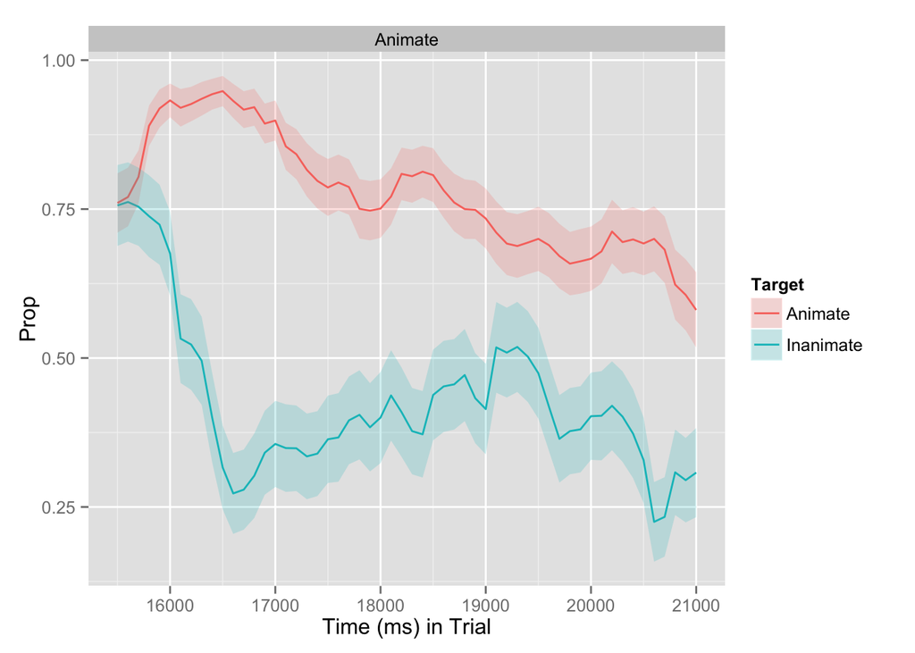

```r
data_summary <- describe_data(response_window, data_options, dv='Animate', factors=c('ParticipantName','Target'))

# aggregate across trials within subjects in time analysis
response_time <- make_time_data(response_window, data_options, time_bin_size = 100,
                                 predictor_columns = c("Target"),
                                 aoi = c("Animate")
                            )

# visualize time results
plot(response_time, data_options, predictor_column = "Target")
```

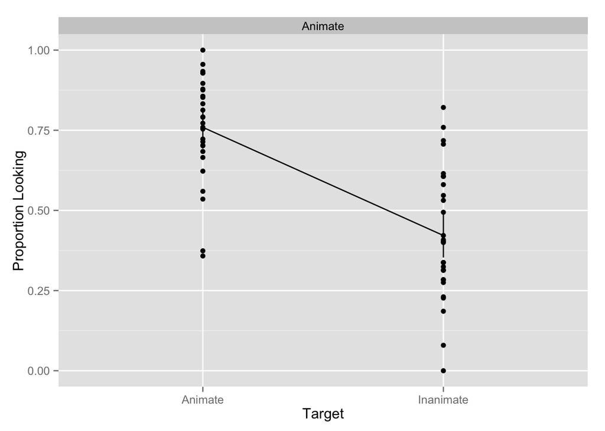

```r
# aggregate by subject across the response window
response_window_agg <- make_window_data(response_window, data_options, aoi='Animate', predictor_columns=c('Target','Age','MCDI_Total'))

# take a quick peek at mean proportion by Target condition
# note this automatically aggregates across trials by subjects
plot(response_window_agg, data_options, x_axis_column="Target")
```

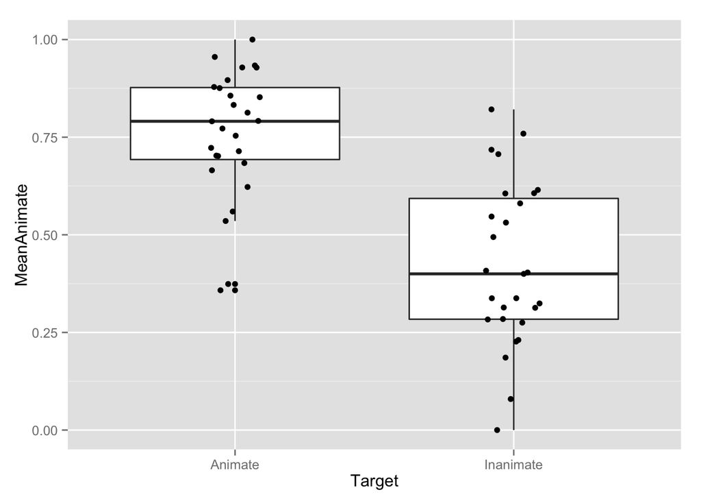

```r
subject_means <- response_window_agg %>%
                          group_by(ParticipantName,Target,Age,MCDI_Total) %>%
                          summarise(MeanAnimate = mean(Prop,na.rm=T), N=length(Prop), ArcSin = asin(sqrt(MeanAnimate))) %>%
                          ungroup()

# visualize our aggregated data with a boxplot (data should match previous plot)
ggplot(subject_means, aes(x=Target, y=MeanAnimate)) +
                                  geom_boxplot() +
                                  geom_point(position=position_jitter(.1))
```

```r
# show condition means
condition_means <- subject_means %>%
                    group_by(Target) %>%
                    summarise(Mean=mean(MeanAnimate), SD=sd(MeanAnimate), N=length(MeanAnimate))

condition_means
```

```
## Source: local data frame [2 x 4]
##
##      Target      Mean        SD     N
##      (fctr)     (dbl)     (dbl) (int)
## 1   Animate 0.7592257 0.1642998    27
## 2 Inanimate 0.4217769 0.2092836    27
```

## Simple t-test

```r
# simple t-test between conditions
t.test(ArcSin ~ Target, data=subject_means, paired=T)
```

```
##
##  Paired t-test
##
## data:  ArcSin by Target
## t = 7.2337, df = 26, p-value = 1.108e-07
## alternative hypothesis: true difference in means is not equal to 0
## 95 percent confidence interval:
##  0.2805509 0.5032884
## sample estimates:
## mean of the differences
##               0.3919196
```

## Mixed-effects models on windowed data

```r
# mixed-effects linear model on subject*trial data
response_window_agg$TargetC <- ifelse(response_window_agg$Target == 'Animate', .5, -.5)
response_window_agg$TargetC <- scale(response_window_agg$TargetC, center=T, scale=F)

model <- lmer(Elog ~ TargetC + (1 + TargetC | Trial) + (1 | ParticipantName), data = response_window_agg, REML = F)
summary(model)
```

```
## Linear mixed model fit by maximum likelihood  ['lmerMod']
## Formula: Elog ~ TargetC + (1 + TargetC | Trial) + (1 | ParticipantName)
##    Data: response_window_agg
##
##      AIC      BIC   logLik deviance df.resid
##    502.1    521.6   -244.0    488.1      114
##
## Scaled residuals:
##     Min      1Q  Median      3Q     Max
## -2.8298 -0.6062 -0.1254  0.4959  2.6248
##
## Random effects:
##  Groups          Name        Variance  Std.Dev.  Corr
##  ParticipantName (Intercept) 4.953e-01 7.038e-01
##  Trial           (Intercept) 0.000e+00 0.000e+00
##                  TargetC     6.307e-15 7.941e-08  NaN
##  Residual                    2.920e+00 1.709e+00
## Number of obs: 121, groups:  ParticipantName, 27; Trial, 6
##
## Fixed effects:
##             Estimate Std. Error t value
## (Intercept)   1.1413     0.2086   5.470
## TargetC       2.4855     0.3245   7.661
##
## Correlation of Fixed Effects:
##         (Intr)
## TargetC 0.005
```

```r
drop1(model,~.,test="Chi")
```

```
## Single term deletions
##
## Model:
## Elog ~ TargetC + (1 + TargetC | Trial) + (1 | ParticipantName)
##         Df    AIC    LRT  Pr(Chi)
## <none>     502.05
## TargetC  1 509.02 8.9602 0.002759 **
## ---
## Signif. codes:  0 '***' 0.001 '**' 0.01 '*' 0.05 '.' 0.1 ' ' 1
```

## Growth curve analysis

```r
# growth curve analysis on time series
response_time$TargetC <- ifelse(response_time$Target == 'Animate', .5, -.5)
response_time$TargetC <- scale(response_time$TargetC, center=T, scale=F)

model <- lmer(Elog ~ TargetC*(ot1 + ot2 + ot3 + ot4 + ot5) + (1 | Trial) + (1 | ParticipantName), data = response_time, REML = F)
summary(model)
```

```
## Linear mixed model fit by maximum likelihood  ['lmerMod']
## Formula: Elog ~ TargetC * (ot1 + ot2 + ot3 + ot4 + ot5) + (1 | Trial) +
##     (1 | ParticipantName)
##    Data: response_time
##
##      AIC      BIC   logLik deviance df.resid
##  28269.0  28370.8 -14119.5  28239.0     6545
##
## Scaled residuals:
##     Min      1Q  Median      3Q     Max
## -2.6080 -0.8771  0.2872  0.6795  2.0702
##
## Random effects:
##  Groups          Name        Variance Std.Dev.
##  ParticipantName (Intercept) 0.42628  0.6529
##  Trial           (Intercept) 0.02103  0.1450
##  Residual                    4.27329  2.0672
## Number of obs: 6560, groups:  ParticipantName, 27; Trial, 6
##
## Fixed effects:
##             Estimate Std. Error t value
## (Intercept)   0.7148     0.1416   5.047
## TargetC       1.7340     0.1368  12.675
## ot1          -2.9040     0.1934 -15.019
## ot2           0.2677     0.1937   1.382
## ot3          -0.6158     0.1933  -3.186
## ot4          -0.2628     0.1927  -1.364
## ot5           0.5999     0.1931   3.106
## TargetC:ot1  -1.0124     0.4011  -2.524
## TargetC:ot2  -1.9643     0.4019  -4.887
## TargetC:ot3   3.8307     0.4010   9.553
## TargetC:ot4  -2.3421     0.4001  -5.854
## TargetC:ot5  -0.4444     0.4010  -1.108
##
## Correlation of Fixed Effects:
##             (Intr) TargtC ot1    ot2    ot3    ot4    ot5    TrgC:1 TrgC:2
## TargetC     -0.023
## ot1          0.003  0.002
## ot2          0.006  0.003  0.024
## ot3          0.001  0.002  0.032  0.021
## ot4          0.003  0.001  0.010  0.028  0.022
## ot5          0.000  0.000  0.012  0.011  0.024  0.020
## TargetC:ot1  0.001  0.006  0.005  0.009  0.005  0.004  0.003
## TargetC:ot2  0.001  0.008  0.009  0.005  0.008  0.007  0.007  0.019
## TargetC:ot3  0.001  0.003  0.005  0.008  0.006  0.010  0.005  0.028  0.017
## TargetC:ot4  0.000  0.004  0.004  0.007  0.010  0.004  0.007  0.007  0.024
## TargetC:ot5  0.000  0.000  0.003  0.007  0.005  0.007  0.005  0.010  0.007
##             TrgC:3 TrgC:4
## TargetC
## ot1
## ot2
## ot3
## ot4
## ot5
## TargetC:ot1
## TargetC:ot2
## TargetC:ot3
## TargetC:ot4  0.017
## TargetC:ot5  0.021  0.016
```

```r
drop1(model,~.,test="Chi")
```

```
## Single term deletions
##
## Model:
## Elog ~ TargetC * (ot1 + ot2 + ot3 + ot4 + ot5) + (1 | Trial) +
##     (1 | ParticipantName)
##             Df   AIC     LRT   Pr(Chi)
## <none>         28269
## TargetC      1 28286  19.298 1.118e-05 ***
## ot1          1 28489 221.772 < 2.2e-16 ***
## ot2          1 28269   1.910  0.167002
## ot3          1 28277  10.140  0.001451 **
## ot4          1 28269   1.860  0.172635
## ot5          1 28277   9.643  0.001901 **
## TargetC:ot1  1 28273   6.368  0.011622 *
## TargetC:ot2  1 28291  23.841 1.047e-06 ***
## TargetC:ot3  1 28358  90.636 < 2.2e-16 ***
## TargetC:ot4  1 28301  34.175 5.038e-09 ***
## TargetC:ot5  1 28268   1.228  0.267717
## ---
## Signif. codes:  0 '***' 0.001 '**' 0.01 '*' 0.05 '.' 0.1 ' ' 1
```

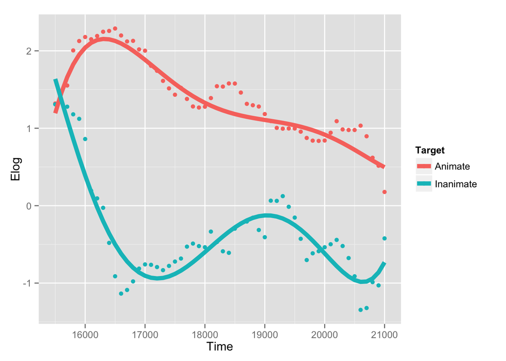

```r
# visualize GCA model
ggplot(response_time, aes(x=Time, y=Elog, color=Target)) +
  stat_summary(fun.y=mean, geom="point") +
  stat_summary(aes(y=predict(model,response_time,re.form=NA)), fun.y=mean, geom="line", linetype='solid', size=2)
```

## Onset-contingent analysis

```r
# recode AOIs to target & distractor
response_window$TrialTarget <- ifelse(response_window$Target == 'Animate', response_window$Animate, response_window$Inanimate)
response_window$TrialDistractor <- ifelse(response_window$Target == 'Animate', response_window$Inanimate, response_window$Animate)

onsets <- make_onset_data(response_window, data_options, onset_time = 15500, fixation_window_length = 100, target_aoi='TrialTarget')
```

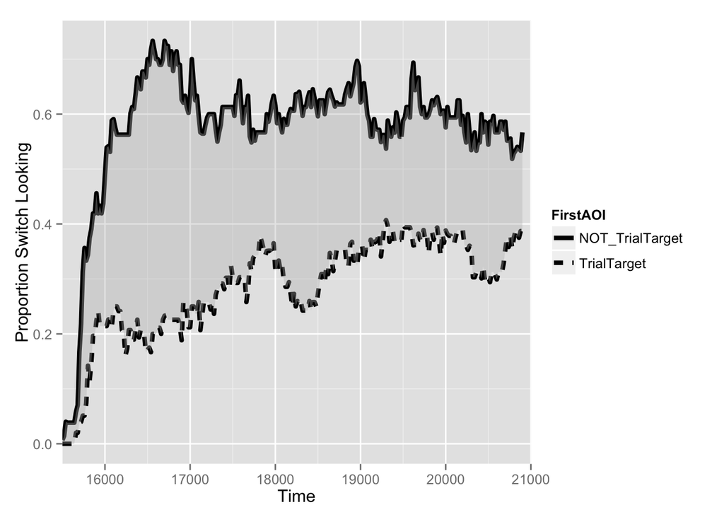

```r
plot(onsets, data_options)
```

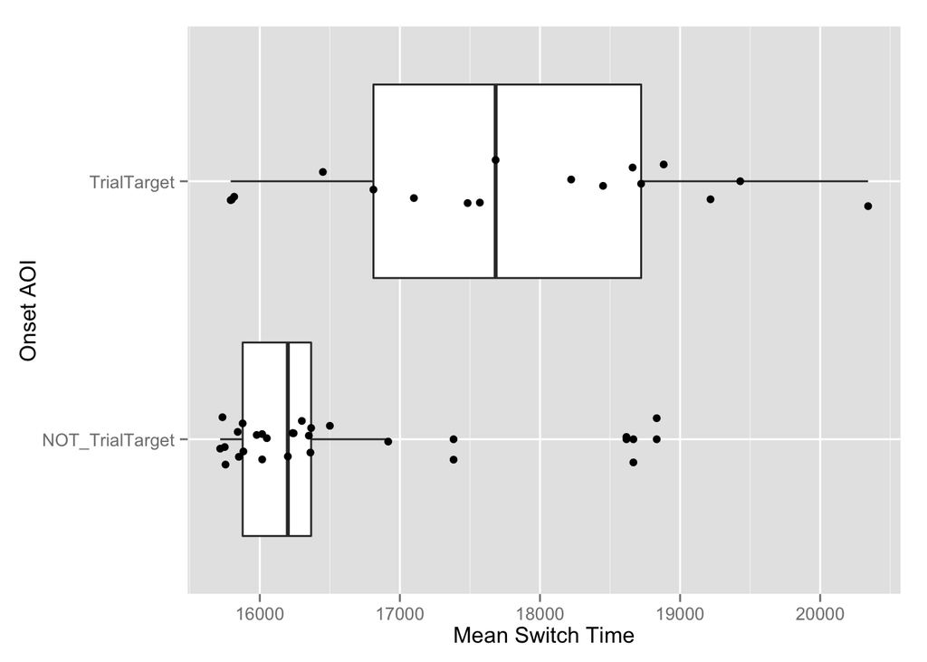

```r
# compare switch times
onset_switches <- make_switch_data(onsets, data_options)

plot(onset_switches, data_options)
```

```r
onset_switches$FirstAOIC <- ifelse(onset_switches$FirstAOI == 'TrialTarget', .5, -.5)
onset_switches$FirstAOIC <- scale(onset_switches$FirstAOIC, center=T, scale=F)

model <- lmer(FirstSwitch ~ FirstAOIC + (1 + FirstAOIC | Trial) + (1 + FirstAOIC | ParticipantName), data=onset_switches, REML=F)
summary(model)
```

```
## Linear mixed model fit by maximum likelihood  ['lmerMod']
## Formula:
## FirstSwitch ~ FirstAOIC + (1 + FirstAOIC | Trial) + (1 + FirstAOIC |
##     ParticipantName)
##    Data: onset_switches
##
##      AIC      BIC   logLik deviance df.resid
##   1742.0   1765.7   -862.0   1724.0       94
##
## Scaled residuals:
##     Min      1Q  Median      3Q     Max
## -1.3951 -0.5914 -0.1854  0.2959  2.3788
##
## Random effects:
##  Groups          Name        Variance Std.Dev. Corr
##  ParticipantName (Intercept)  320262   565.9
##                  FirstAOIC   1566606  1251.6   0.90
##  Trial           (Intercept)   29484   171.7
##                  FirstAOIC    832048   912.2   1.00
##  Residual                     657783   811.0
## Number of obs: 103, groups:  ParticipantName, 26; Trial, 6
##
## Fixed effects:
##             Estimate Std. Error t value
## (Intercept)  16980.9      167.3   101.5
## FirstAOIC     1494.9      482.0     3.1
##
## Correlation of Fixed Effects:
##           (Intr)
## FirstAOIC 0.685
```

```r
drop1(model,~.,test="Chi")
```

```
## Single term deletions
##
## Model:
## FirstSwitch ~ FirstAOIC + (1 + FirstAOIC | Trial) + (1 + FirstAOIC |
##     ParticipantName)
##           Df    AIC    LRT Pr(Chi)
## <none>       1742.0
## FirstAOIC  1 1746.2 6.2459 0.01245 *
## ---
## Signif. codes:  0 '***' 0.001 '**' 0.01 '*' 0.05 '.' 0.1 ' ' 1
```

## Bootstrapped splines analysis.

Do a proper within-subjects analysis for the familiar trials.

```r
bootstrapped_familiar <- make_bootstrapped_data(response_time, data_options, predictor_column = 'Target', within_subj = TRUE, samples = 1000, resolution = 100, alpha = .05, smoother = 'smooth.spline')
```

```
## Preparing dataframe...
## Resampling ...
```

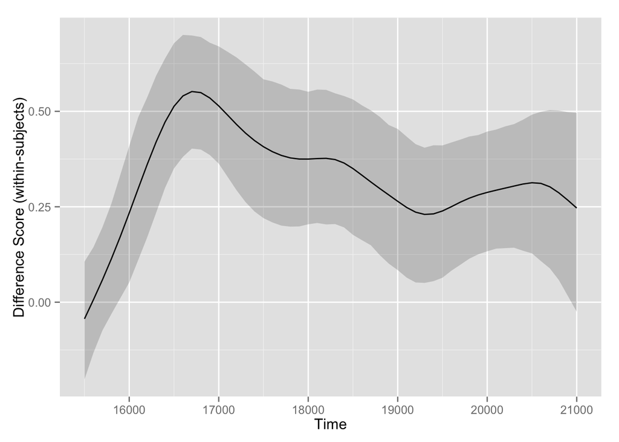

```r
plot(bootstrapped_familiar, data_options)
```

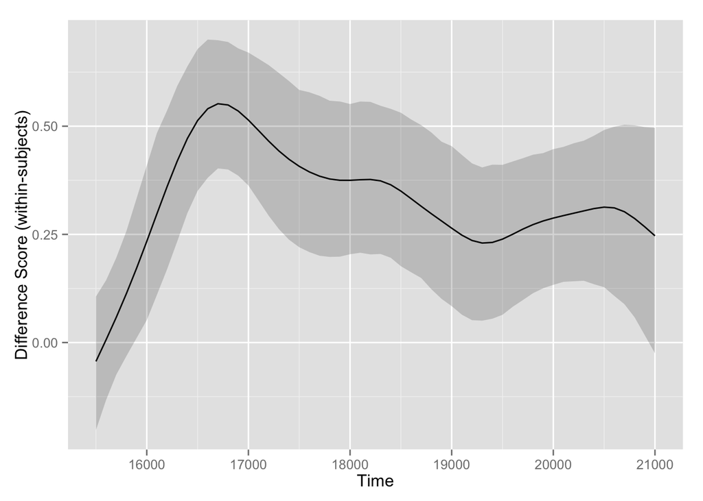

```r
bootstrap_analysis_familiar <- analyze_bootstraps(bootstrapped_familiar, data_options)

# same as above, because, for within-subjects data, it always plots the difference score estimates
plot(bootstrap_analysis_familiar, data_options) # TO DO: this should tell you in which direction the difference was taken
```

```r
summary(bootstrap_analysis_familiar, data_options)
```

[output not shown]

## Cluster Analysis

Perform a different type of bootstrapping analyses (Maris & Oostenveld, 2007), sometimes referred to as a cluster analysis. This analysis takes a summed statistic for each cluster of time bins that pass some level of significance, and compares each to the “null” distribution of sum statistics (obtained by bootstrap resampling data within the largest of the clusters).

This type of analysis should often give similar results to the above, with the main advantage is that it can be used with several types of statistical techniques (t.test, wilcox.test, lm, and lmer), so that continuous predictors, covariates, etc. can be included in the model being tested; and the main disadvantage is that it is slower.

```r
response_time_by_subj <- make_time_data(response_window, data_options, time_bin_size = 100,
                                 predictor_columns = c("Target"),
                                 aoi = c("Animate"),
                                 summarize_by = "ParticipantName"
                            )

df_timeclust = make_time_cluster_data(response_time_by_subj, data_options,
                                      test= "t.test", paired = TRUE,
                                      predictor_column = "Target",
                                      threshold = 2)
```

```
## Computing t.test for each time bin...
```

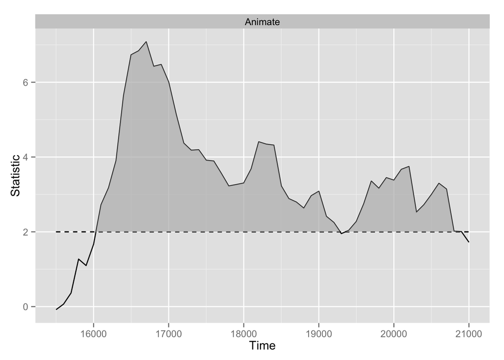

```r
plot(df_timeclust)
```

```r
clust_analysis = analyze_time_clusters(df_timeclust, data_options, within_subj = TRUE, paired=TRUE)
clust_analysis
```

```
## Test Type:    t.test
## IV:       Target
## Null Distribution =====
##  Mean:    0.61697
##  SD:  25.60049
## Cluster 1  =====
##  Time:        16100 - 19200
##  Sum Statistic:   133.0288
##  Probability:     0
## Cluster 2  =====
##  Time:        19400 - 20900
##  Sum Statistic:   46.51971
##  Probability:     0.033
```

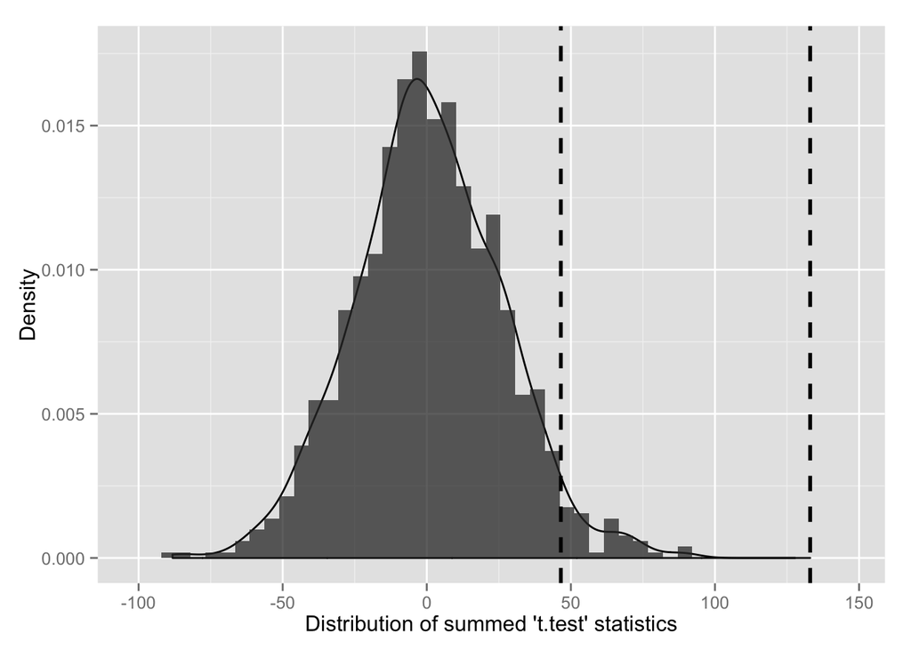

```r
plot(clust_analysis)
```